# Risk Factor Analysis

## Outcome Variable

**Outcome Variable:** haz

## Predictor Variables

**Intervention Variable:** predfeed3

**Adjustment Set:**

unadjusted

## Stratifying Variables

The analysis was stratified on these variable(s):

- agecat
- studyid
- country

## Data Summary

| agecat | studyid | country | predfeed3 | n_cell | n |
| --- | --- | --- | --- | --- | --- |
| Birth | ki0047075b-MAL-ED | BANGLADESH | 1 | 205 | 240 |
| Birth | ki0047075b-MAL-ED | BANGLADESH | 0 | 35 | 240 |
| Birth | ki0047075b-MAL-ED | BRAZIL | 1 | 101 | 185 |
| Birth | ki0047075b-MAL-ED | BRAZIL | 0 | 84 | 185 |
| Birth | ki0047075b-MAL-ED | INDIA | 1 | 152 | 196 |
| Birth | ki0047075b-MAL-ED | INDIA | 0 | 44 | 196 |
| Birth | ki0047075b-MAL-ED | NEPAL | 1 | 99 | 171 |
| Birth | ki0047075b-MAL-ED | NEPAL | 0 | 72 | 171 |
| Birth | ki0047075b-MAL-ED | PERU | 1 | 183 | 272 |
| Birth | ki0047075b-MAL-ED | PERU | 0 | 89 | 272 |
| Birth | ki0047075b-MAL-ED | SOUTH AFRICA | 1 | 87 | 233 |
| Birth | ki0047075b-MAL-ED | SOUTH AFRICA | 0 | 146 | 233 |
| Birth | ki0047075b-MAL-ED | TANZANIA, UNITED REPUBLIC OF | 1 | 50 | 119 |
| Birth | ki0047075b-MAL-ED | TANZANIA, UNITED REPUBLIC OF | 0 | 69 | 119 |
| Birth | ki1000109-EE | PAKISTAN | 1 | 2 | 2 |
| Birth | ki1000109-EE | PAKISTAN | 0 | 0 | 2 |
| Birth | kiGH5241-JiVitA-3 | BANGLADESH | 1 | 16832 | 18710 |
| Birth | kiGH5241-JiVitA-3 | BANGLADESH | 0 | 1878 | 18710 |
| Birth | kiGH5241-JiVitA-4 | BANGLADESH | 1 | 37 | 40 |
| Birth | kiGH5241-JiVitA-4 | BANGLADESH | 0 | 3 | 40 |
| 6 months | ki0047075b-MAL-ED | BANGLADESH | 1 | 203 | 237 |
| 6 months | ki0047075b-MAL-ED | BANGLADESH | 0 | 34 | 237 |
| 6 months | ki0047075b-MAL-ED | BRAZIL | 1 | 116 | 209 |
| 6 months | ki0047075b-MAL-ED | BRAZIL | 0 | 93 | 209 |
| 6 months | ki0047075b-MAL-ED | INDIA | 1 | 178 | 233 |
| 6 months | ki0047075b-MAL-ED | INDIA | 0 | 55 | 233 |
| 6 months | ki0047075b-MAL-ED | NEPAL | 1 | 132 | 233 |
| 6 months | ki0047075b-MAL-ED | NEPAL | 0 | 101 | 233 |
| 6 months | ki0047075b-MAL-ED | PERU | 1 | 183 | 270 |
| 6 months | ki0047075b-MAL-ED | PERU | 0 | 87 | 270 |
| 6 months | ki0047075b-MAL-ED | SOUTH AFRICA | 1 | 86 | 248 |
| 6 months | ki0047075b-MAL-ED | SOUTH AFRICA | 0 | 162 | 248 |
| 6 months | ki0047075b-MAL-ED | TANZANIA, UNITED REPUBLIC OF | 1 | 91 | 240 |
| 6 months | ki0047075b-MAL-ED | TANZANIA, UNITED REPUBLIC OF | 0 | 149 | 240 |
| 6 months | ki1000109-EE | PAKISTAN | 1 | 346 | 371 |
| 6 months | ki1000109-EE | PAKISTAN | 0 | 25 | 371 |
| 6 months | ki1113344-GMS-Nepal | NEPAL | 1 | 379 | 458 |
| 6 months | ki1113344-GMS-Nepal | NEPAL | 0 | 79 | 458 |
| 6 months | kiGH5241-JiVitA-3 | BANGLADESH | 1 | 14797 | 16281 |
| 6 months | kiGH5241-JiVitA-3 | BANGLADESH | 0 | 1484 | 16281 |
| 6 months | kiGH5241-JiVitA-4 | BANGLADESH | 1 | 77 | 89 |
| 6 months | kiGH5241-JiVitA-4 | BANGLADESH | 0 | 12 | 89 |
| 24 months | ki0047075b-MAL-ED | BANGLADESH | 1 | 178 | 208 |
| 24 months | ki0047075b-MAL-ED | BANGLADESH | 0 | 30 | 208 |
| 24 months | ki0047075b-MAL-ED | BRAZIL | 1 | 98 | 169 |
| 24 months | ki0047075b-MAL-ED | BRAZIL | 0 | 71 | 169 |
| 24 months | ki0047075b-MAL-ED | INDIA | 1 | 170 | 225 |
| 24 months | ki0047075b-MAL-ED | INDIA | 0 | 55 | 225 |
| 24 months | ki0047075b-MAL-ED | NEPAL | 1 | 128 | 225 |
| 24 months | ki0047075b-MAL-ED | NEPAL | 0 | 97 | 225 |
| 24 months | ki0047075b-MAL-ED | PERU | 1 | 137 | 199 |
| 24 months | ki0047075b-MAL-ED | PERU | 0 | 62 | 199 |
| 24 months | ki0047075b-MAL-ED | SOUTH AFRICA | 1 | 81 | 232 |
| 24 months | ki0047075b-MAL-ED | SOUTH AFRICA | 0 | 151 | 232 |
| 24 months | ki0047075b-MAL-ED | TANZANIA, UNITED REPUBLIC OF | 1 | 79 | 210 |
| 24 months | ki0047075b-MAL-ED | TANZANIA, UNITED REPUBLIC OF | 0 | 131 | 210 |
| 24 months | ki1113344-GMS-Nepal | NEPAL | 1 | 336 | 404 |
| 24 months | ki1113344-GMS-Nepal | NEPAL | 0 | 68 | 404 |
| 24 months | kiGH5241-JiVitA-3 | BANGLADESH | 1 | 7520 | 8341 |
| 24 months | kiGH5241-JiVitA-3 | BANGLADESH | 0 | 821 | 8341 |
| 24 months | kiGH5241-JiVitA-4 | BANGLADESH | 1 | 137 | 152 |
| 24 months | kiGH5241-JiVitA-4 | BANGLADESH | 0 | 15 | 152 |

The following strata were considered:

- agecat: 24 months, studyid: ki0047075b-MAL-ED, country: BANGLADESH
- agecat: 24 months, studyid: ki0047075b-MAL-ED, country: BRAZIL
- agecat: 24 months, studyid: ki0047075b-MAL-ED, country: INDIA
- agecat: 24 months, studyid: ki0047075b-MAL-ED, country: NEPAL
- agecat: 24 months, studyid: ki0047075b-MAL-ED, country: PERU
- agecat: 24 months, studyid: ki0047075b-MAL-ED, country: SOUTH AFRICA
- agecat: 24 months, studyid: ki0047075b-MAL-ED, country: TANZANIA, UNITED REPUBLIC OF
- agecat: 24 months, studyid: ki1113344-GMS-Nepal, country: NEPAL
- agecat: 24 months, studyid: kiGH5241-JiVitA-3, country: BANGLADESH
- agecat: 24 months, studyid: kiGH5241-JiVitA-4, country: BANGLADESH
- agecat: 6 months, studyid: ki0047075b-MAL-ED, country: BANGLADESH
- agecat: 6 months, studyid: ki0047075b-MAL-ED, country: BRAZIL
- agecat: 6 months, studyid: ki0047075b-MAL-ED, country: INDIA
- agecat: 6 months, studyid: ki0047075b-MAL-ED, country: NEPAL
- agecat: 6 months, studyid: ki0047075b-MAL-ED, country: PERU
- agecat: 6 months, studyid: ki0047075b-MAL-ED, country: SOUTH AFRICA
- agecat: 6 months, studyid: ki0047075b-MAL-ED, country: TANZANIA, UNITED REPUBLIC OF
- agecat: 6 months, studyid: ki1000109-EE, country: PAKISTAN
- agecat: 6 months, studyid: ki1113344-GMS-Nepal, country: NEPAL
- agecat: 6 months, studyid: kiGH5241-JiVitA-3, country: BANGLADESH
- agecat: 6 months, studyid: kiGH5241-JiVitA-4, country: BANGLADESH
- agecat: Birth, studyid: ki0047075b-MAL-ED, country: BANGLADESH
- agecat: Birth, studyid: ki0047075b-MAL-ED, country: BRAZIL
- agecat: Birth, studyid: ki0047075b-MAL-ED, country: INDIA
- agecat: Birth, studyid: ki0047075b-MAL-ED, country: NEPAL
- agecat: Birth, studyid: ki0047075b-MAL-ED, country: PERU
- agecat: Birth, studyid: ki0047075b-MAL-ED, country: SOUTH AFRICA
- agecat: Birth, studyid: ki0047075b-MAL-ED, country: TANZANIA, UNITED REPUBLIC OF
- agecat: Birth, studyid: ki1000109-EE, country: PAKISTAN
- agecat: Birth, studyid: kiGH5241-JiVitA-3, country: BANGLADESH
- agecat: Birth, studyid: kiGH5241-JiVitA-4, country: BANGLADESH

### Dropped Strata

Some strata were dropped due to rare outcomes:

- agecat: Birth, studyid: ki1000109-EE, country: PAKISTAN
- agecat: Birth, studyid: kiGH5241-JiVitA-4, country: BANGLADESH

## Methods Detail

We’re interested in the causal parameters $E[Y_a]$ for all values of $a \in \mathcal{A}$. These parameters represent the mean outcome if, possibly contrary to fact, we intervened to set all units to have $A=a$. Under the randomization and positivity assumptions, these are identified by the statistical parameters $\psi_a=E_W[E_{Y|A,W}(Y|A=a,W)]$. In addition, we’re interested in the mean of $Y$, $E[Y]$ under no intervention (the observed mean). We will estimate these parameters by using SuperLearner to fit the relevant likelihood factors – $E_{Y|A,W}(Y|A=a,W)$ and $p(A=a|W)$, and then updating our likelihood fit using a joint TMLE.

For unadjusted analyses ($W=\{\}$), initial likelihoods were estimated using Lrnr_glm to estimate the simple $E(Y|A)$ and Lrnr_mean to estimate $p(A)$. For adjusted analyses, a small library containing Lrnr_glmnet, Lrnr_xgboost, and Lrnr_mean was used.

Having estimated these parameters, we will then use the delta method to estimate relative risks and attributable risks relative to a prespecified baseline level of $A$.

# Results Detail

## Results Plots

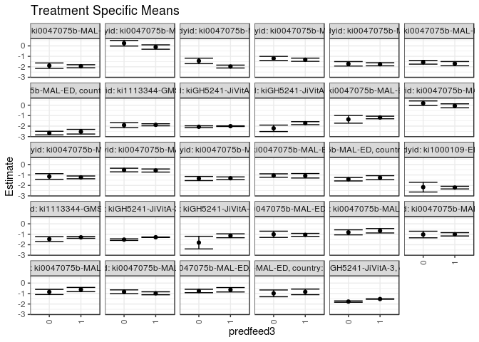

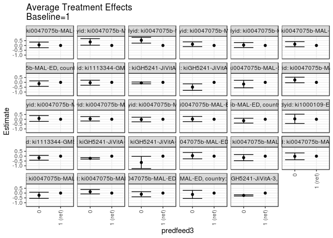

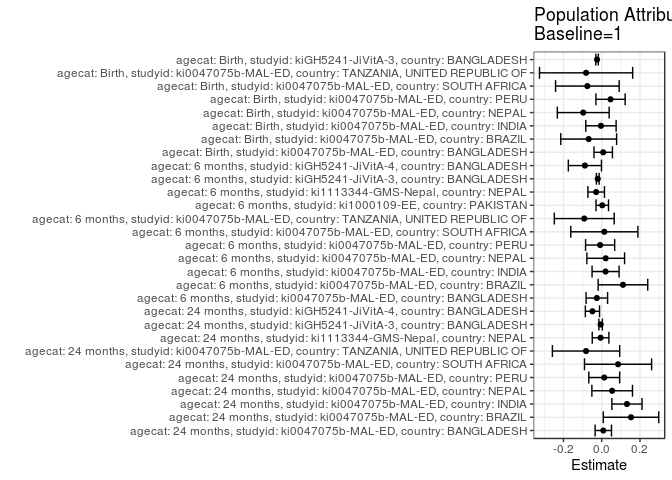

## Results Table

### Parameter: TSM

| agecat | studyid | country | intervention_level | baseline_level | estimate | ci_lower | ci_upper |
| --- | --- | --- | --- | --- | --- | --- | --- |
| Birth | ki0047075b-MAL-ED | BANGLADESH | 1 | NA | -1.0574634 | -1.1988504 | -0.9160764 |
| Birth | ki0047075b-MAL-ED | BANGLADESH | 0 | NA | -1.0042857 | -1.3026870 | -0.7058844 |
| Birth | ki0047075b-MAL-ED | BRAZIL | 1 | NA | -0.6669307 | -0.8776456 | -0.4562158 |
| Birth | ki0047075b-MAL-ED | BRAZIL | 0 | NA | -0.8170238 | -1.0585025 | -0.5755451 |
| Birth | ki0047075b-MAL-ED | INDIA | 1 | NA | -1.0057895 | -1.1646774 | -0.8469015 |
| Birth | ki0047075b-MAL-ED | INDIA | 0 | NA | -1.0238636 | -1.3392137 | -0.7085136 |
| Birth | ki0047075b-MAL-ED | NEPAL | 1 | NA | -0.6161616 | -0.8193899 | -0.4129333 |
| Birth | ki0047075b-MAL-ED | NEPAL | 0 | NA | -0.8456944 | -1.0917250 | -0.5996639 |
| Birth | ki0047075b-MAL-ED | PERU | 1 | NA | -0.9721858 | -1.1131838 | -0.8311878 |
| Birth | ki0047075b-MAL-ED | PERU | 0 | NA | -0.8314607 | -1.0162269 | -0.6466945 |
| Birth | ki0047075b-MAL-ED | SOUTH AFRICA | 1 | NA | -0.6357471 | -0.8459388 | -0.4255554 |
| Birth | ki0047075b-MAL-ED | SOUTH AFRICA | 0 | NA | -0.7556164 | -0.9169358 | -0.5942970 |
| Birth | ki0047075b-MAL-ED | TANZANIA, UNITED REPUBLIC OF | 1 | NA | -0.8388000 | -1.1058572 | -0.5717428 |
| Birth | ki0047075b-MAL-ED | TANZANIA, UNITED REPUBLIC OF | 0 | NA | -0.9798551 | -1.3031755 | -0.6565346 |
| Birth | kiGH5241-JiVitA-3 | BANGLADESH | 1 | NA | -1.5213124 | -1.5411358 | -1.5014889 |
| Birth | kiGH5241-JiVitA-3 | BANGLADESH | 0 | NA | -1.7647710 | -1.8296846 | -1.6998575 |
| 6 months | ki0047075b-MAL-ED | BANGLADESH | 1 | NA | -1.1753530 | -1.2995263 | -1.0511798 |
| 6 months | ki0047075b-MAL-ED | BANGLADESH | 0 | NA | -1.3539216 | -1.7214291 | -0.9864140 |
| 6 months | ki0047075b-MAL-ED | BRAZIL | 1 | NA | -0.0598851 | -0.2497564 | 0.1299863 |
| 6 months | ki0047075b-MAL-ED | BRAZIL | 0 | NA | 0.1893548 | -0.0280498 | 0.4067595 |
| 6 months | ki0047075b-MAL-ED | INDIA | 1 | NA | -1.2310300 | -1.3630436 | -1.0990163 |
| 6 months | ki0047075b-MAL-ED | INDIA | 0 | NA | -1.1459697 | -1.4136312 | -0.8783082 |
| 6 months | ki0047075b-MAL-ED | NEPAL | 1 | NA | -0.5766667 | -0.7245557 | -0.4287777 |
| 6 months | ki0047075b-MAL-ED | NEPAL | 0 | NA | -0.5285149 | -0.7009199 | -0.3561098 |
| 6 months | ki0047075b-MAL-ED | PERU | 1 | NA | -1.3145082 | -1.4426465 | -1.1863699 |
| 6 months | ki0047075b-MAL-ED | PERU | 0 | NA | -1.3405939 | -1.5387642 | -1.1424236 |
| 6 months | ki0047075b-MAL-ED | SOUTH AFRICA | 1 | NA | -1.0777519 | -1.2910404 | -0.8644635 |
| 6 months | ki0047075b-MAL-ED | SOUTH AFRICA | 0 | NA | -1.0567541 | -1.2199042 | -0.8936040 |
| 6 months | ki0047075b-MAL-ED | TANZANIA, UNITED REPUBLIC OF | 1 | NA | -1.2603663 | -1.4521023 | -1.0686303 |
| 6 months | ki0047075b-MAL-ED | TANZANIA, UNITED REPUBLIC OF | 0 | NA | -1.4073937 | -1.5704056 | -1.2443818 |
| 6 months | ki1000109-EE | PAKISTAN | 1 | NA | -2.2085405 | -2.3358767 | -2.0812042 |
| 6 months | ki1000109-EE | PAKISTAN | 0 | NA | -2.1658000 | -2.6320343 | -1.6995657 |
| 6 months | ki1113344-GMS-Nepal | NEPAL | 1 | NA | -1.2945646 | -1.3876531 | -1.2014762 |
| 6 months | ki1113344-GMS-Nepal | NEPAL | 0 | NA | -1.4624895 | -1.6925949 | -1.2323840 |
| 6 months | kiGH5241-JiVitA-3 | BANGLADESH | 1 | NA | -1.2853491 | -1.3087039 | -1.2619942 |
| 6 months | kiGH5241-JiVitA-3 | BANGLADESH | 0 | NA | -1.5122170 | -1.5900152 | -1.4344187 |
| 6 months | kiGH5241-JiVitA-4 | BANGLADESH | 1 | NA | -1.1459740 | -1.3308960 | -0.9610521 |
| 6 months | kiGH5241-JiVitA-4 | BANGLADESH | 0 | NA | -1.7983333 | -2.4033116 | -1.1933551 |
| 24 months | ki0047075b-MAL-ED | BANGLADESH | 1 | NA | -1.9474438 | -2.0897089 | -1.8051788 |
| 24 months | ki0047075b-MAL-ED | BANGLADESH | 0 | NA | -1.8900000 | -2.1491988 | -1.6308012 |
| 24 months | ki0047075b-MAL-ED | BRAZIL | 1 | NA | -0.1112755 | -0.3201955 | 0.0976445 |
| 24 months | ki0047075b-MAL-ED | BRAZIL | 0 | NA | 0.2531690 | -0.0134314 | 0.5197695 |
| 24 months | ki0047075b-MAL-ED | INDIA | 1 | NA | -1.9752353 | -2.1146708 | -1.8357998 |
| 24 months | ki0047075b-MAL-ED | INDIA | 0 | NA | -1.4357273 | -1.6988331 | -1.1726215 |
| 24 months | ki0047075b-MAL-ED | NEPAL | 1 | NA | -1.3239844 | -1.4764644 | -1.1715044 |
| 24 months | ki0047075b-MAL-ED | NEPAL | 0 | NA | -1.1973196 | -1.3895220 | -1.0051172 |
| 24 months | ki0047075b-MAL-ED | PERU | 1 | NA | -1.7570803 | -1.9036464 | -1.6105142 |
| 24 months | ki0047075b-MAL-ED | PERU | 0 | NA | -1.7151613 | -1.9283419 | -1.5019807 |
| 24 months | ki0047075b-MAL-ED | SOUTH AFRICA | 1 | NA | -1.6967901 | -1.8959053 | -1.4976750 |
| 24 months | ki0047075b-MAL-ED | SOUTH AFRICA | 0 | NA | -1.5656623 | -1.7469572 | -1.3843673 |
| 24 months | ki0047075b-MAL-ED | TANZANIA, UNITED REPUBLIC OF | 1 | NA | -2.5339873 | -2.7566192 | -2.3113555 |
| 24 months | ki0047075b-MAL-ED | TANZANIA, UNITED REPUBLIC OF | 0 | NA | -2.6654198 | -2.8378134 | -2.4930263 |
| 24 months | ki1113344-GMS-Nepal | NEPAL | 1 | NA | -1.8727976 | -1.9717463 | -1.7738489 |
| 24 months | ki1113344-GMS-Nepal | NEPAL | 0 | NA | -1.9084804 | -2.1468994 | -1.6700614 |
| 24 months | kiGH5241-JiVitA-3 | BANGLADESH | 1 | NA | -2.0054734 | -2.0344836 | -1.9764632 |
| 24 months | kiGH5241-JiVitA-3 | BANGLADESH | 0 | NA | -2.0634470 | -2.1550593 | -1.9718347 |
| 24 months | kiGH5241-JiVitA-4 | BANGLADESH | 1 | NA | -1.7186131 | -1.8623416 | -1.5748846 |
| 24 months | kiGH5241-JiVitA-4 | BANGLADESH | 0 | NA | -2.2100000 | -2.5176955 | -1.9023045 |

### Parameter: E(Y)

| agecat | studyid | country | intervention_level | baseline_level | estimate | ci_lower | ci_upper |
| --- | --- | --- | --- | --- | --- | --- | --- |
| Birth | ki0047075b-MAL-ED | BANGLADESH | NA | NA | -1.0497083 | -1.1780996 | -0.9213171 |
| Birth | ki0047075b-MAL-ED | BRAZIL | NA | NA | -0.7350811 | -0.8943683 | -0.5757938 |
| Birth | ki0047075b-MAL-ED | INDIA | NA | NA | -1.0098469 | -1.1519586 | -0.8677353 |
| Birth | ki0047075b-MAL-ED | NEPAL | NA | NA | -0.7128070 | -0.8704934 | -0.5551207 |
| Birth | ki0047075b-MAL-ED | PERU | NA | NA | -0.9261397 | -1.0389037 | -0.8133757 |
| Birth | ki0047075b-MAL-ED | SOUTH AFRICA | NA | NA | -0.7108584 | -0.8390511 | -0.5826657 |
| Birth | ki0047075b-MAL-ED | TANZANIA, UNITED REPUBLIC OF | NA | NA | -0.9205882 | -1.1394357 | -0.7017408 |
| Birth | kiGH5241-JiVitA-3 | BANGLADESH | NA | NA | -1.5457493 | -1.5650991 | -1.5263996 |
| 6 months | ki0047075b-MAL-ED | BANGLADESH | NA | NA | -1.2009705 | -1.3199485 | -1.0819924 |
| 6 months | ki0047075b-MAL-ED | BRAZIL | NA | NA | 0.0510207 | -0.0930194 | 0.1950608 |
| 6 months | ki0047075b-MAL-ED | INDIA | NA | NA | -1.2109514 | -1.3300505 | -1.0918522 |
| 6 months | ki0047075b-MAL-ED | NEPAL | NA | NA | -0.5557940 | -0.6681063 | -0.4434817 |
| 6 months | ki0047075b-MAL-ED | PERU | NA | NA | -1.3229136 | -1.4307207 | -1.2151065 |
| 6 months | ki0047075b-MAL-ED | SOUTH AFRICA | NA | NA | -1.0640356 | -1.1937663 | -0.9343049 |
| 6 months | ki0047075b-MAL-ED | TANZANIA, UNITED REPUBLIC OF | NA | NA | -1.3516458 | -1.4765824 | -1.2267092 |
| 6 months | ki1000109-EE | PAKISTAN | NA | NA | -2.2056604 | -2.3285064 | -2.0828144 |
| 6 months | ki1113344-GMS-Nepal | NEPAL | NA | NA | -1.3235298 | -1.4103807 | -1.2366790 |
| 6 months | kiGH5241-JiVitA-3 | BANGLADESH | NA | NA | -1.3060279 | -1.3292905 | -1.2827653 |
| 6 months | kiGH5241-JiVitA-4 | BANGLADESH | NA | NA | -1.2339326 | -1.4137041 | -1.0541611 |
| 24 months | ki0047075b-MAL-ED | BANGLADESH | NA | NA | -1.9391587 | -2.0665449 | -1.8117724 |
| 24 months | ki0047075b-MAL-ED | BRAZIL | NA | NA | 0.0418343 | -0.1253834 | 0.2090521 |
| 24 months | ki0047075b-MAL-ED | INDIA | NA | NA | -1.8433556 | -1.9704665 | -1.7162446 |
| 24 months | ki0047075b-MAL-ED | NEPAL | NA | NA | -1.2693778 | -1.3896188 | -1.1491367 |
| 24 months | ki0047075b-MAL-ED | PERU | NA | NA | -1.7440201 | -1.8648503 | -1.6231899 |
| 24 months | ki0047075b-MAL-ED | SOUTH AFRICA | NA | NA | -1.6114440 | -1.7486349 | -1.4742530 |
| 24 months | ki0047075b-MAL-ED | TANZANIA, UNITED REPUBLIC OF | NA | NA | -2.6159762 | -2.7525555 | -2.4793968 |
| 24 months | ki1113344-GMS-Nepal | NEPAL | NA | NA | -1.8788036 | -1.9703700 | -1.7872372 |
| 24 months | kiGH5241-JiVitA-3 | BANGLADESH | NA | NA | -2.0111797 | -2.0396837 | -1.9826758 |
| 24 months | kiGH5241-JiVitA-4 | BANGLADESH | NA | NA | -1.7671053 | -1.9017670 | -1.6324435 |

### Parameter: ATE

| agecat | studyid | country | intervention_level | baseline_level | estimate | ci_lower | ci_upper |
| --- | --- | --- | --- | --- | --- | --- | --- |
| Birth | ki0047075b-MAL-ED | BANGLADESH | 1 | 1 | 0.0000000 | 0.0000000 | 0.0000000 |
| Birth | ki0047075b-MAL-ED | BANGLADESH | 0 | 1 | 0.0531777 | -0.2770247 | 0.3833801 |
| Birth | ki0047075b-MAL-ED | BRAZIL | 1 | 1 | 0.0000000 | 0.0000000 | 0.0000000 |
| Birth | ki0047075b-MAL-ED | BRAZIL | 0 | 1 | -0.1500931 | -0.4705813 | 0.1703951 |
| Birth | ki0047075b-MAL-ED | INDIA | 1 | 1 | 0.0000000 | 0.0000000 | 0.0000000 |
| Birth | ki0047075b-MAL-ED | INDIA | 0 | 1 | -0.0180742 | -0.3711904 | 0.3350420 |
| Birth | ki0047075b-MAL-ED | NEPAL | 1 | 1 | 0.0000000 | 0.0000000 | 0.0000000 |
| Birth | ki0047075b-MAL-ED | NEPAL | 0 | 1 | -0.2295328 | -0.5486453 | 0.0895796 |
| Birth | ki0047075b-MAL-ED | PERU | 1 | 1 | 0.0000000 | 0.0000000 | 0.0000000 |
| Birth | ki0047075b-MAL-ED | PERU | 0 | 1 | 0.1407251 | -0.0916947 | 0.3731450 |
| Birth | ki0047075b-MAL-ED | SOUTH AFRICA | 1 | 1 | 0.0000000 | 0.0000000 | 0.0000000 |
| Birth | ki0047075b-MAL-ED | SOUTH AFRICA | 0 | 1 | -0.1198693 | -0.3848306 | 0.1450920 |
| Birth | ki0047075b-MAL-ED | TANZANIA, UNITED REPUBLIC OF | 1 | 1 | 0.0000000 | 0.0000000 | 0.0000000 |
| Birth | ki0047075b-MAL-ED | TANZANIA, UNITED REPUBLIC OF | 0 | 1 | -0.1410551 | -0.5604066 | 0.2782964 |
| Birth | kiGH5241-JiVitA-3 | BANGLADESH | 1 | 1 | 0.0000000 | 0.0000000 | 0.0000000 |
| Birth | kiGH5241-JiVitA-3 | BANGLADESH | 0 | 1 | -0.2434587 | -0.3100936 | -0.1768237 |
| 6 months | ki0047075b-MAL-ED | BANGLADESH | 1 | 1 | 0.0000000 | 0.0000000 | 0.0000000 |
| 6 months | ki0047075b-MAL-ED | BANGLADESH | 0 | 1 | -0.1785685 | -0.5664871 | 0.2093500 |
| 6 months | ki0047075b-MAL-ED | BRAZIL | 1 | 1 | 0.0000000 | 0.0000000 | 0.0000000 |
| 6 months | ki0047075b-MAL-ED | BRAZIL | 0 | 1 | 0.2492399 | -0.0394051 | 0.5378848 |
| 6 months | ki0047075b-MAL-ED | INDIA | 1 | 1 | 0.0000000 | 0.0000000 | 0.0000000 |
| 6 months | ki0047075b-MAL-ED | INDIA | 0 | 1 | 0.0850603 | -0.2133862 | 0.3835067 |
| 6 months | ki0047075b-MAL-ED | NEPAL | 1 | 1 | 0.0000000 | 0.0000000 | 0.0000000 |
| 6 months | ki0047075b-MAL-ED | NEPAL | 0 | 1 | 0.0481518 | -0.1789927 | 0.2752964 |
| 6 months | ki0047075b-MAL-ED | PERU | 1 | 1 | 0.0000000 | 0.0000000 | 0.0000000 |
| 6 months | ki0047075b-MAL-ED | PERU | 0 | 1 | -0.0260857 | -0.2620748 | 0.2099035 |
| 6 months | ki0047075b-MAL-ED | SOUTH AFRICA | 1 | 1 | 0.0000000 | 0.0000000 | 0.0000000 |
| 6 months | ki0047075b-MAL-ED | SOUTH AFRICA | 0 | 1 | 0.0209978 | -0.2475351 | 0.2895307 |
| 6 months | ki0047075b-MAL-ED | TANZANIA, UNITED REPUBLIC OF | 1 | 1 | 0.0000000 | 0.0000000 | 0.0000000 |
| 6 months | ki0047075b-MAL-ED | TANZANIA, UNITED REPUBLIC OF | 0 | 1 | -0.1470274 | -0.3986930 | 0.1046382 |
| 6 months | ki1000109-EE | PAKISTAN | 1 | 1 | 0.0000000 | 0.0000000 | 0.0000000 |
| 6 months | ki1000109-EE | PAKISTAN | 0 | 1 | 0.0427405 | -0.4405699 | 0.5260508 |
| 6 months | ki1113344-GMS-Nepal | NEPAL | 1 | 1 | 0.0000000 | 0.0000000 | 0.0000000 |
| 6 months | ki1113344-GMS-Nepal | NEPAL | 0 | 1 | -0.1679248 | -0.4161465 | 0.0802969 |
| 6 months | kiGH5241-JiVitA-3 | BANGLADESH | 1 | 1 | 0.0000000 | 0.0000000 | 0.0000000 |
| 6 months | kiGH5241-JiVitA-3 | BANGLADESH | 0 | 1 | -0.2268679 | -0.3047857 | -0.1489502 |
| 6 months | kiGH5241-JiVitA-4 | BANGLADESH | 1 | 1 | 0.0000000 | 0.0000000 | 0.0000000 |
| 6 months | kiGH5241-JiVitA-4 | BANGLADESH | 0 | 1 | -0.6523593 | -1.2845608 | -0.0201578 |
| 24 months | ki0047075b-MAL-ED | BANGLADESH | 1 | 1 | 0.0000000 | 0.0000000 | 0.0000000 |
| 24 months | ki0047075b-MAL-ED | BANGLADESH | 0 | 1 | 0.0574438 | -0.2382306 | 0.3531182 |
| 24 months | ki0047075b-MAL-ED | BRAZIL | 1 | 1 | 0.0000000 | 0.0000000 | 0.0000000 |
| 24 months | ki0047075b-MAL-ED | BRAZIL | 0 | 1 | 0.3644445 | 0.0257361 | 0.7031529 |
| 24 months | ki0047075b-MAL-ED | INDIA | 1 | 1 | 0.0000000 | 0.0000000 | 0.0000000 |
| 24 months | ki0047075b-MAL-ED | INDIA | 0 | 1 | 0.5395080 | 0.2417381 | 0.8372780 |
| 24 months | ki0047075b-MAL-ED | NEPAL | 1 | 1 | 0.0000000 | 0.0000000 | 0.0000000 |
| 24 months | ki0047075b-MAL-ED | NEPAL | 0 | 1 | 0.1266648 | -0.1186756 | 0.3720052 |
| 24 months | ki0047075b-MAL-ED | PERU | 1 | 1 | 0.0000000 | 0.0000000 | 0.0000000 |
| 24 months | ki0047075b-MAL-ED | PERU | 0 | 1 | 0.0419190 | -0.2167847 | 0.3006227 |
| 24 months | ki0047075b-MAL-ED | SOUTH AFRICA | 1 | 1 | 0.0000000 | 0.0000000 | 0.0000000 |
| 24 months | ki0047075b-MAL-ED | SOUTH AFRICA | 0 | 1 | 0.1311279 | -0.1381577 | 0.4004134 |
| 24 months | ki0047075b-MAL-ED | TANZANIA, UNITED REPUBLIC OF | 1 | 1 | 0.0000000 | 0.0000000 | 0.0000000 |
| 24 months | ki0047075b-MAL-ED | TANZANIA, UNITED REPUBLIC OF | 0 | 1 | -0.1314325 | -0.4130075 | 0.1501425 |
| 24 months | ki1113344-GMS-Nepal | NEPAL | 1 | 1 | 0.0000000 | 0.0000000 | 0.0000000 |
| 24 months | ki1113344-GMS-Nepal | NEPAL | 0 | 1 | -0.0356828 | -0.2938193 | 0.2224538 |
| 24 months | kiGH5241-JiVitA-3 | BANGLADESH | 1 | 1 | 0.0000000 | 0.0000000 | 0.0000000 |
| 24 months | kiGH5241-JiVitA-3 | BANGLADESH | 0 | 1 | -0.0579736 | -0.1511462 | 0.0351990 |
| 24 months | kiGH5241-JiVitA-4 | BANGLADESH | 1 | 1 | 0.0000000 | 0.0000000 | 0.0000000 |
| 24 months | kiGH5241-JiVitA-4 | BANGLADESH | 0 | 1 | -0.4913869 | -0.8299679 | -0.1528058 |

### Parameter: PAR

| agecat | studyid | country | intervention_level | baseline_level | estimate | ci_lower | ci_upper |
| --- | --- | --- | --- | --- | --- | --- | --- |
| Birth | ki0047075b-MAL-ED | BANGLADESH | 1 | NA | 0.0077551 | -0.0404582 | 0.0559684 |
| Birth | ki0047075b-MAL-ED | BRAZIL | 1 | NA | -0.0681504 | -0.2140694 | 0.0777686 |
| Birth | ki0047075b-MAL-ED | INDIA | 1 | NA | -0.0040575 | -0.0833355 | 0.0752206 |
| Birth | ki0047075b-MAL-ED | NEPAL | 1 | NA | -0.0966454 | -0.2320842 | 0.0387934 |
| Birth | ki0047075b-MAL-ED | PERU | 1 | NA | 0.0460461 | -0.0304083 | 0.1225005 |
| Birth | ki0047075b-MAL-ED | SOUTH AFRICA | 1 | NA | -0.0751112 | -0.2413061 | 0.0910836 |
| Birth | ki0047075b-MAL-ED | TANZANIA, UNITED REPUBLIC OF | 1 | NA | -0.0817882 | -0.3252659 | 0.1616894 |
| Birth | kiGH5241-JiVitA-3 | BANGLADESH | 1 | NA | -0.0244370 | -0.0311157 | -0.0177582 |
| 6 months | ki0047075b-MAL-ED | BANGLADESH | 1 | NA | -0.0256174 | -0.0818383 | 0.0306034 |
| 6 months | ki0047075b-MAL-ED | BRAZIL | 1 | NA | 0.1109058 | -0.0186326 | 0.2404442 |
| 6 months | ki0047075b-MAL-ED | INDIA | 1 | NA | 0.0200786 | -0.0505233 | 0.0906805 |
| 6 months | ki0047075b-MAL-ED | NEPAL | 1 | NA | 0.0208727 | -0.0776370 | 0.1193823 |
| 6 months | ki0047075b-MAL-ED | PERU | 1 | NA | -0.0084054 | -0.0844603 | 0.0676495 |
| 6 months | ki0047075b-MAL-ED | SOUTH AFRICA | 1 | NA | 0.0137163 | -0.1617007 | 0.1891334 |
| 6 months | ki0047075b-MAL-ED | TANZANIA, UNITED REPUBLIC OF | 1 | NA | -0.0912795 | -0.2477834 | 0.0652244 |
| 6 months | ki1000109-EE | PAKISTAN | 1 | NA | 0.0028801 | -0.0297063 | 0.0354665 |
| 6 months | ki1113344-GMS-Nepal | NEPAL | 1 | NA | -0.0289652 | -0.0721740 | 0.0142436 |
| 6 months | kiGH5241-JiVitA-3 | BANGLADESH | 1 | NA | -0.0206788 | -0.0277834 | -0.0135743 |
| 6 months | kiGH5241-JiVitA-4 | BANGLADESH | 1 | NA | -0.0879586 | -0.1745577 | -0.0013594 |
| 24 months | ki0047075b-MAL-ED | BANGLADESH | 1 | NA | 0.0082852 | -0.0344487 | 0.0510190 |
| 24 months | ki0047075b-MAL-ED | BRAZIL | 1 | NA | 0.1531098 | 0.0082358 | 0.2979839 |
| 24 months | ki0047075b-MAL-ED | INDIA | 1 | NA | 0.1318797 | 0.0530125 | 0.2107470 |
| 24 months | ki0047075b-MAL-ED | NEPAL | 1 | NA | 0.0546066 | -0.0514809 | 0.1606941 |
| 24 months | ki0047075b-MAL-ED | PERU | 1 | NA | 0.0130602 | -0.0675863 | 0.0937067 |
| 24 months | ki0047075b-MAL-ED | SOUTH AFRICA | 1 | NA | 0.0853462 | -0.0901069 | 0.2607992 |
| 24 months | ki0047075b-MAL-ED | TANZANIA, UNITED REPUBLIC OF | 1 | NA | -0.0819888 | -0.2578500 | 0.0938723 |
| 24 months | ki1113344-GMS-Nepal | NEPAL | 1 | NA | -0.0060060 | -0.0494743 | 0.0374623 |
| 24 months | kiGH5241-JiVitA-3 | BANGLADESH | 1 | NA | -0.0057063 | -0.0148576 | 0.0034450 |
| 24 months | kiGH5241-JiVitA-4 | BANGLADESH | 1 | NA | -0.0484921 | -0.0855697 | -0.0114146 |